# Risk Factor Analysis

## Outcome Variable

**Outcome Variable:** ever_co

## Predictor Variables

**Intervention Variable:** mage

**Adjustment Set:**

- arm
- meducyrs
- feducyrs
- W_mhtcm
- W_mwtkg
- W_mbmi
- single
- delta_meducyrs
- delta_feducyrs
- delta_W_mhtcm
- delta_W_mwtkg
- delta_W_mbmi
- delta_single

## Stratifying Variables

The analysis was stratified on these variable(s):

- agecat
- studyid
- country

## Data Summary

| agecat | studyid | country | mage | ever_co | n_cell | n |
| --- | --- | --- | --- | --- | --- | --- |
| 0-24 months | CMC-V-BCS-2002 | INDIA | [20-30) | 0 | 225 | 373 |
| 0-24 months | CMC-V-BCS-2002 | INDIA | [20-30) | 1 | 71 | 373 |
| 0-24 months | CMC-V-BCS-2002 | INDIA | <20 | 0 | 27 | 373 |
| 0-24 months | CMC-V-BCS-2002 | INDIA | <20 | 1 | 7 | 373 |
| 0-24 months | CMC-V-BCS-2002 | INDIA | >=30 | 0 | 35 | 373 |
| 0-24 months | CMC-V-BCS-2002 | INDIA | >=30 | 1 | 8 | 373 |
| 0-24 months | COHORTS | GUATEMALA | [20-30) | 0 | 579 | 1341 |
| 0-24 months | COHORTS | GUATEMALA | [20-30) | 1 | 76 | 1341 |
| 0-24 months | COHORTS | GUATEMALA | <20 | 0 | 179 | 1341 |
| 0-24 months | COHORTS | GUATEMALA | <20 | 1 | 17 | 1341 |
| 0-24 months | COHORTS | GUATEMALA | >=30 | 0 | 435 | 1341 |
| 0-24 months | COHORTS | GUATEMALA | >=30 | 1 | 55 | 1341 |
| 0-24 months | COHORTS | INDIA | [20-30) | 0 | 3279 | 5303 |
| 0-24 months | COHORTS | INDIA | [20-30) | 1 | 317 | 5303 |
| 0-24 months | COHORTS | INDIA | <20 | 0 | 377 | 5303 |
| 0-24 months | COHORTS | INDIA | <20 | 1 | 49 | 5303 |
| 0-24 months | COHORTS | INDIA | >=30 | 0 | 1127 | 5303 |
| 0-24 months | COHORTS | INDIA | >=30 | 1 | 154 | 5303 |
| 0-24 months | COHORTS | PHILIPPINES | [20-30) | 0 | 1513 | 3045 |
| 0-24 months | COHORTS | PHILIPPINES | [20-30) | 1 | 307 | 3045 |
| 0-24 months | COHORTS | PHILIPPINES | <20 | 0 | 292 | 3045 |
| 0-24 months | COHORTS | PHILIPPINES | <20 | 1 | 85 | 3045 |
| 0-24 months | COHORTS | PHILIPPINES | >=30 | 0 | 680 | 3045 |
| 0-24 months | COHORTS | PHILIPPINES | >=30 | 1 | 168 | 3045 |
| 0-24 months | EE | PAKISTAN | [20-30) | 0 | 95 | 377 |
| 0-24 months | EE | PAKISTAN | [20-30) | 1 | 67 | 377 |
| 0-24 months | EE | PAKISTAN | <20 | 0 | 0 | 377 |
| 0-24 months | EE | PAKISTAN | <20 | 1 | 1 | 377 |
| 0-24 months | EE | PAKISTAN | >=30 | 0 | 114 | 377 |
| 0-24 months | EE | PAKISTAN | >=30 | 1 | 100 | 377 |

[output cut: 450 more lines]

The following strata were considered:

- agecat: 0-24 months, studyid: CMC-V-BCS-2002, country: INDIA
- agecat: 0-24 months, studyid: COHORTS, country: GUATEMALA
- agecat: 0-24 months, studyid: COHORTS, country: INDIA
- agecat: 0-24 months, studyid: COHORTS, country: PHILIPPINES
- agecat: 0-24 months, studyid: EE, country: PAKISTAN
- agecat: 0-24 months, studyid: GMS-Nepal, country: NEPAL
- agecat: 0-24 months, studyid: Guatemala BSC, country: GUATEMALA
- agecat: 0-24 months, studyid: iLiNS-Zinc, country: BURKINA FASO
- agecat: 0-24 months, studyid: IRC, country: INDIA
- agecat: 0-24 months, studyid: JiVitA-3, country: BANGLADESH
- agecat: 0-24 months, studyid: Keneba, country: GAMBIA
- agecat: 0-24 months, studyid: LCNI-5, country: MALAWI
- agecat: 0-24 months, studyid: MAL-ED, country: BANGLADESH
- agecat: 0-24 months, studyid: MAL-ED, country: BRAZIL
- agecat: 0-24 months, studyid: MAL-ED, country: INDIA
- agecat: 0-24 months, studyid: MAL-ED, country: NEPAL
- agecat: 0-24 months, studyid: MAL-ED, country: PERU
- agecat: 0-24 months, studyid: MAL-ED, country: SOUTH AFRICA
- agecat: 0-24 months, studyid: MAL-ED, country: TANZANIA, UNITED REPUBLIC OF
- agecat: 0-24 months, studyid: NIH-Birth, country: BANGLADESH
- agecat: 0-24 months, studyid: NIH-Crypto, country: BANGLADESH
- agecat: 0-24 months, studyid: PROBIT, country: BELARUS
- agecat: 0-24 months, studyid: PROVIDE, country: BANGLADESH
- agecat: 0-24 months, studyid: SAS-CompFeed, country: INDIA
- agecat: 0-24 months, studyid: SAS-FoodSuppl, country: INDIA
- agecat: 0-24 months, studyid: TanzaniaChild2, country: TANZANIA, UNITED REPUBLIC OF
- agecat: 0-24 months, studyid: ZVITAMBO, country: ZIMBABWE
- agecat: 0-6 months, studyid: CMC-V-BCS-2002, country: INDIA
- agecat: 0-6 months, studyid: COHORTS, country: GUATEMALA
- agecat: 0-6 months, studyid: COHORTS, country: INDIA
- agecat: 0-6 months, studyid: COHORTS, country: PHILIPPINES
- agecat: 0-6 months, studyid: EE, country: PAKISTAN
- agecat: 0-6 months, studyid: GMS-Nepal, country: NEPAL
- agecat: 0-6 months, studyid: Guatemala BSC, country: GUATEMALA
- agecat: 0-6 months, studyid: IRC, country: INDIA
- agecat: 0-6 months, studyid: JiVitA-3, country: BANGLADESH
- agecat: 0-6 months, studyid: Keneba, country: GAMBIA
- agecat: 0-6 months, studyid: LCNI-5, country: MALAWI
- agecat: 0-6 months, studyid: MAL-ED, country: BANGLADESH
- agecat: 0-6 months, studyid: MAL-ED, country: BRAZIL
- agecat: 0-6 months, studyid: MAL-ED, country: INDIA
- agecat: 0-6 months, studyid: MAL-ED, country: NEPAL
- agecat: 0-6 months, studyid: MAL-ED, country: PERU
- agecat: 0-6 months, studyid: MAL-ED, country: SOUTH AFRICA
- agecat: 0-6 months, studyid: MAL-ED, country: TANZANIA, UNITED REPUBLIC OF
- agecat: 0-6 months, studyid: NIH-Birth, country: BANGLADESH
- agecat: 0-6 months, studyid: NIH-Crypto, country: BANGLADESH
- agecat: 0-6 months, studyid: PROBIT, country: BELARUS
- agecat: 0-6 months, studyid: PROVIDE, country: BANGLADESH
- agecat: 0-6 months, studyid: SAS-CompFeed, country: INDIA
- agecat: 0-6 months, studyid: SAS-FoodSuppl, country: INDIA
- agecat: 0-6 months, studyid: TanzaniaChild2, country: TANZANIA, UNITED REPUBLIC OF
- agecat: 0-6 months, studyid: ZVITAMBO, country: ZIMBABWE
- agecat: 6-24 months, studyid: CMC-V-BCS-2002, country: INDIA
- agecat: 6-24 months, studyid: COHORTS, country: GUATEMALA
- agecat: 6-24 months, studyid: COHORTS, country: INDIA
- agecat: 6-24 months, studyid: COHORTS, country: PHILIPPINES
- agecat: 6-24 months, studyid: EE, country: PAKISTAN
- agecat: 6-24 months, studyid: GMS-Nepal, country: NEPAL
- agecat: 6-24 months, studyid: Guatemala BSC, country: GUATEMALA
- agecat: 6-24 months, studyid: iLiNS-Zinc, country: BURKINA FASO
- agecat: 6-24 months, studyid: IRC, country: INDIA
- agecat: 6-24 months, studyid: JiVitA-3, country: BANGLADESH
- agecat: 6-24 months, studyid: Keneba, country: GAMBIA
- agecat: 6-24 months, studyid: LCNI-5, country: MALAWI
- agecat: 6-24 months, studyid: MAL-ED, country: BANGLADESH
- agecat: 6-24 months, studyid: MAL-ED, country: BRAZIL
- agecat: 6-24 months, studyid: MAL-ED, country: INDIA
- agecat: 6-24 months, studyid: MAL-ED, country: NEPAL
- agecat: 6-24 months, studyid: MAL-ED, country: PERU
- agecat: 6-24 months, studyid: MAL-ED, country: SOUTH AFRICA
- agecat: 6-24 months, studyid: MAL-ED, country: TANZANIA, UNITED REPUBLIC OF
- agecat: 6-24 months, studyid: NIH-Birth, country: BANGLADESH
- agecat: 6-24 months, studyid: NIH-Crypto, country: BANGLADESH
- agecat: 6-24 months, studyid: PROBIT, country: BELARUS
- agecat: 6-24 months, studyid: PROVIDE, country: BANGLADESH
- agecat: 6-24 months, studyid: SAS-CompFeed, country: INDIA
- agecat: 6-24 months, studyid: SAS-FoodSuppl, country: INDIA
- agecat: 6-24 months, studyid: TanzaniaChild2, country: TANZANIA, UNITED REPUBLIC OF
- agecat: 6-24 months, studyid: ZVITAMBO, country: ZIMBABWE

### Dropped Strata

Some strata were dropped due to rare outcomes:

- agecat: 0-24 months, studyid: EE, country: PAKISTAN
- agecat: 0-24 months, studyid: MAL-ED, country: BRAZIL
- agecat: 0-24 months, studyid: MAL-ED, country: INDIA
- agecat: 0-24 months, studyid: MAL-ED, country: NEPAL
- agecat: 0-24 months, studyid: MAL-ED, country: PERU
- agecat: 0-24 months, studyid: MAL-ED, country: SOUTH AFRICA
- agecat: 0-24 months, studyid: MAL-ED, country: TANZANIA, UNITED REPUBLIC OF
- agecat: 0-24 months, studyid: PROBIT, country: BELARUS
- agecat: 0-6 months, studyid: CMC-V-BCS-2002, country: INDIA
- agecat: 0-6 months, studyid: COHORTS, country: GUATEMALA
- agecat: 0-6 months, studyid: EE, country: PAKISTAN
- agecat: 0-6 months, studyid: Guatemala BSC, country: GUATEMALA
- agecat: 0-6 months, studyid: IRC, country: INDIA
- agecat: 0-6 months, studyid: LCNI-5, country: MALAWI
- agecat: 0-6 months, studyid: MAL-ED, country: BANGLADESH
- agecat: 0-6 months, studyid: MAL-ED, country: BRAZIL
- agecat: 0-6 months, studyid: MAL-ED, country: INDIA
- agecat: 0-6 months, studyid: MAL-ED, country: NEPAL
- agecat: 0-6 months, studyid: MAL-ED, country: PERU
- agecat: 0-6 months, studyid: MAL-ED, country: SOUTH AFRICA
- agecat: 0-6 months, studyid: MAL-ED, country: TANZANIA, UNITED REPUBLIC OF
- agecat: 0-6 months, studyid: NIH-Birth, country: BANGLADESH
- agecat: 0-6 months, studyid: NIH-Crypto, country: BANGLADESH
- agecat: 0-6 months, studyid: PROBIT, country: BELARUS
- agecat: 0-6 months, studyid: PROVIDE, country: BANGLADESH
- agecat: 0-6 months, studyid: SAS-FoodSuppl, country: INDIA
- agecat: 0-6 months, studyid: TanzaniaChild2, country: TANZANIA, UNITED REPUBLIC OF
- agecat: 6-24 months, studyid: EE, country: PAKISTAN
- agecat: 6-24 months, studyid: Guatemala BSC, country: GUATEMALA
- agecat: 6-24 months, studyid: MAL-ED, country: BRAZIL
- agecat: 6-24 months, studyid: MAL-ED, country: INDIA
- agecat: 6-24 months, studyid: MAL-ED, country: NEPAL
- agecat: 6-24 months, studyid: MAL-ED, country: PERU
- agecat: 6-24 months, studyid: MAL-ED, country: SOUTH AFRICA
- agecat: 6-24 months, studyid: MAL-ED, country: TANZANIA, UNITED REPUBLIC OF
- agecat: 6-24 months, studyid: PROBIT, country: BELARUS

## Methods Detail

We’re interested in the causal parameters $E[Y_a]$ for all values of $a \in \mathcal{A}$. These parameters represent the mean outcome if, possibly contrary to fact, we intervened to set all units to have $A=a$. Under the randomization and positivity assumptions, these are identified by the statistical parameters $\psi_a=E_W[E_{Y|A,W}(Y|A=a,W)]$. In addition, we’re interested in the mean of $Y$, $E[Y]$ under no intervention (the observed mean). We will estimate these parameters by using SuperLearner to fit the relevant likelihood factors – $E_{Y|A,W}(Y|A=a,W)$ and $p(A=a|W)$, and then updating our likelihood fit using a joint TMLE.

For unadjusted analyses ($W=\{\}$), initial likelihoods were estimated using Lrnr_glm to estimate the simple $E(Y|A)$ and Lrnr_mean to estimate $p(A)$. For adjusted analyses, a small library containing Lrnr_glmnet, Lrnr_xgboost, and Lrnr_mean was used.

Having estimated these parameters, we will then use the delta method to estimate relative risks and attributable risks relative to a prespecified baseline level of $A$.

# Results Detail

## Results Plots

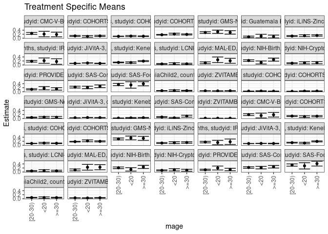

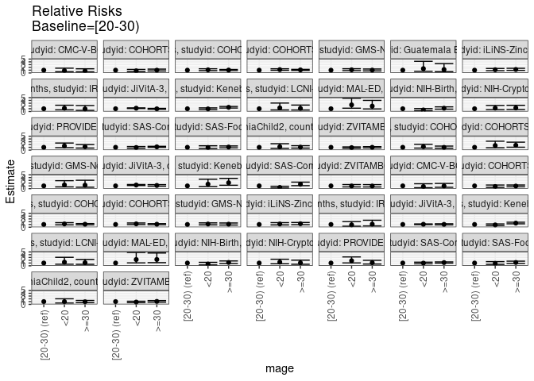

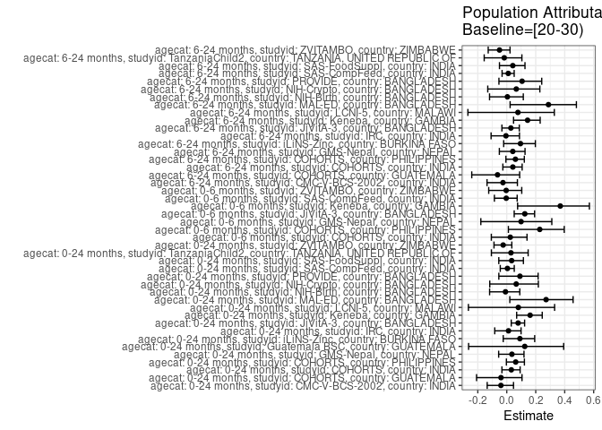

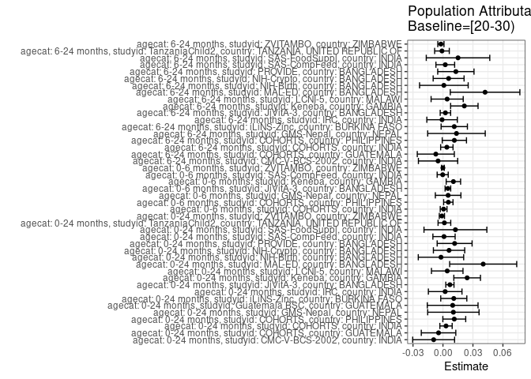

## Results Table

### Parameter: TSM

| agecat | studyid | country | intervention_level | baseline_level | estimate | ci_lower | ci_upper |
| --- | --- | --- | --- | --- | --- | --- | --- |
| 0-24 months | CMC-V-BCS-2002 | INDIA | [20-30) | NA | 0.2398649 | 0.1911553 | 0.2885744 |
| 0-24 months | CMC-V-BCS-2002 | INDIA | <20 | NA | 0.2058824 | 0.0697869 | 0.3419778 |
| 0-24 months | CMC-V-BCS-2002 | INDIA | >=30 | NA | 0.1860465 | 0.0695783 | 0.3025147 |
| 0-24 months | COHORTS | GUATEMALA | [20-30) | NA | 0.1147707 | 0.0901547 | 0.1393868 |
| 0-24 months | COHORTS | GUATEMALA | <20 | NA | 0.0881050 | 0.0471124 | 0.1290976 |
| 0-24 months | COHORTS | GUATEMALA | >=30 | NA | 0.1142001 | 0.0856154 | 0.1427848 |
| 0-24 months | COHORTS | INDIA | [20-30) | NA | 0.0949839 | 0.0851314 | 0.1048363 |
| 0-24 months | COHORTS | INDIA | <20 | NA | 0.1067192 | 0.0767554 | 0.1366831 |
| 0-24 months | COHORTS | INDIA | >=30 | NA | 0.0993318 | 0.0834107 | 0.1152530 |
| 0-24 months | COHORTS | PHILIPPINES | [20-30) | NA | 0.1725733 | 0.1551868 | 0.1899598 |
| 0-24 months | COHORTS | PHILIPPINES | <20 | NA | 0.2076792 | 0.1659914 | 0.2493670 |
| 0-24 months | COHORTS | PHILIPPINES | >=30 | NA | 0.1893934 | 0.1635940 | 0.2151929 |
| 0-24 months | GMS-Nepal | NEPAL | [20-30) | NA | 0.2840357 | 0.2417290 | 0.3263424 |
| 0-24 months | GMS-Nepal | NEPAL | <20 | NA | 0.3211759 | 0.2393747 | 0.4029772 |
| 0-24 months | GMS-Nepal | NEPAL | >=30 | NA | 0.2911033 | 0.2055873 | 0.3766193 |
| 0-24 months | Guatemala BSC | GUATEMALA | [20-30) | NA | 0.0685714 | 0.0310612 | 0.1060816 |
| 0-24 months | Guatemala BSC | GUATEMALA | <20 | NA | 0.1063830 | 0.0180780 | 0.1946879 |
| 0-24 months | Guatemala BSC | GUATEMALA | >=30 | NA | 0.0847458 | 0.0135546 | 0.1559369 |
| 0-24 months | iLiNS-Zinc | BURKINA FASO | [20-30) | NA | 0.1087359 | 0.0863752 | 0.1310966 |
| 0-24 months | iLiNS-Zinc | BURKINA FASO | <20 | NA | 0.1257449 | 0.0809615 | 0.1705283 |
| 0-24 months | iLiNS-Zinc | BURKINA FASO | >=30 | NA | 0.1359078 | 0.1019872 | 0.1698284 |
| 0-24 months | IRC | INDIA | [20-30) | NA | 0.1831395 | 0.1422168 | 0.2240622 |
| 0-24 months | IRC | INDIA | <20 | NA | 0.2162162 | 0.0834096 | 0.3490229 |
| 0-24 months | IRC | INDIA | >=30 | NA | 0.1724138 | 0.0347651 | 0.3100625 |
| 0-24 months | JiVitA-3 | BANGLADESH | [20-30) | NA | 0.0818963 | 0.0764317 | 0.0873609 |
| 0-24 months | JiVitA-3 | BANGLADESH | <20 | NA | 0.0982994 | 0.0918780 | 0.1047207 |
| 0-24 months | JiVitA-3 | BANGLADESH | >=30 | NA | 0.0794601 | 0.0680502 | 0.0908700 |
| 0-24 months | Keneba | GAMBIA | [20-30) | NA | 0.1259493 | 0.1084745 | 0.1434241 |
| 0-24 months | Keneba | GAMBIA | <20 | NA | 0.1191336 | 0.0843664 | 0.1539009 |
| 0-24 months | Keneba | GAMBIA | >=30 | NA | 0.1916172 | 0.1675854 | 0.2156490 |

[output cut: 102 more lines]

### Parameter: E(Y)

| agecat | studyid | country | intervention_level | baseline_level | estimate | ci_lower | ci_upper |
| --- | --- | --- | --- | --- | --- | --- | --- |
| 0-24 months | CMC-V-BCS-2002 | INDIA | NA | NA | 0.2305630 | 0.1877616 | 0.2733644 |
| 0-24 months | COHORTS | GUATEMALA | NA | NA | 0.1103654 | 0.0935883 | 0.1271425 |
| 0-24 months | COHORTS | INDIA | NA | NA | 0.0980577 | 0.0900528 | 0.1060627 |
| 0-24 months | COHORTS | PHILIPPINES | NA | NA | 0.1839080 | 0.1701456 | 0.1976705 |
| 0-24 months | GMS-Nepal | NEPAL | NA | NA | 0.2944606 | 0.2603274 | 0.3285938 |
| 0-24 months | Guatemala BSC | GUATEMALA | NA | NA | 0.0782918 | 0.0468271 | 0.1097565 |
| 0-24 months | iLiNS-Zinc | BURKINA FASO | NA | NA | 0.1195721 | 0.0998202 | 0.1393239 |
| 0-24 months | IRC | INDIA | NA | NA | 0.1853659 | 0.1477057 | 0.2230261 |
| 0-24 months | JiVitA-3 | BANGLADESH | NA | NA | 0.0888451 | 0.0849346 | 0.0927557 |
| 0-24 months | Keneba | GAMBIA | NA | NA | 0.1501575 | 0.1370563 | 0.1632587 |
| 0-24 months | LCNI-5 | MALAWI | NA | NA | 0.0537313 | 0.0366447 | 0.0708180 |
| 0-24 months | MAL-ED | BANGLADESH | NA | NA | 0.1482890 | 0.1052563 | 0.1913216 |
| 0-24 months | NIH-Birth | BANGLADESH | NA | NA | 0.2186495 | 0.1861408 | 0.2511582 |
| 0-24 months | NIH-Crypto | BANGLADESH | NA | NA | 0.0936675 | 0.0729118 | 0.1144233 |
| 0-24 months | PROVIDE | BANGLADESH | NA | NA | 0.1285714 | 0.1037574 | 0.1533855 |
| 0-24 months | SAS-CompFeed | INDIA | NA | NA | 0.2319894 | 0.1917264 | 0.2722524 |
| 0-24 months | SAS-FoodSuppl | INDIA | NA | NA | 0.3708134 | 0.3244530 | 0.4171738 |
| 0-24 months | TanzaniaChild2 | TANZANIA, UNITED REPUBLIC OF | NA | NA | 0.0500842 | 0.0413120 | 0.0588564 |
| 0-24 months | ZVITAMBO | ZIMBABWE | NA | NA | 0.0424338 | 0.0390831 | 0.0457845 |
| 0-6 months | COHORTS | INDIA | NA | NA | 0.0274456 | 0.0229617 | 0.0319295 |
| 0-6 months | COHORTS | PHILIPPINES | NA | NA | 0.0236531 | 0.0182537 | 0.0290525 |
| 0-6 months | GMS-Nepal | NEPAL | NA | NA | 0.0524781 | 0.0357793 | 0.0691770 |
| 0-6 months | JiVitA-3 | BANGLADESH | NA | NA | 0.0396941 | 0.0371916 | 0.0421966 |
| 0-6 months | Keneba | GAMBIA | NA | NA | 0.0282787 | 0.0216999 | 0.0348574 |
| 0-6 months | SAS-CompFeed | INDIA | NA | NA | 0.0704787 | 0.0478990 | 0.0930584 |
| 0-6 months | ZVITAMBO | ZIMBABWE | NA | NA | 0.0120944 | 0.0102712 | 0.0139177 |
| 6-24 months | CMC-V-BCS-2002 | INDIA | NA | NA | 0.1876676 | 0.1479906 | 0.2273445 |
| 6-24 months | COHORTS | GUATEMALA | NA | NA | 0.1123039 | 0.0945135 | 0.1300942 |
| 6-24 months | COHORTS | INDIA | NA | NA | 0.0928355 | 0.0847544 | 0.1009166 |
| 6-24 months | COHORTS | PHILIPPINES | NA | NA | 0.1908832 | 0.1763448 | 0.2054216 |
| 6-24 months | GMS-Nepal | NEPAL | NA | NA | 0.3254237 | 0.2875855 | 0.3632619 |
| 6-24 months | iLiNS-Zinc | BURKINA FASO | NA | NA | 0.1195721 | 0.0998202 | 0.1393239 |
| 6-24 months | IRC | INDIA | NA | NA | 0.1560976 | 0.1209228 | 0.1912723 |
| 6-24 months | JiVitA-3 | BANGLADESH | NA | NA | 0.0868936 | 0.0822329 | 0.0915543 |
| 6-24 months | Keneba | GAMBIA | NA | NA | 0.1489203 | 0.1354543 | 0.1623863 |
| 6-24 months | LCNI-5 | MALAWI | NA | NA | 0.0546282 | 0.0372644 | 0.0719920 |
| 6-24 months | MAL-ED | BANGLADESH | NA | NA | 0.1464435 | 0.1015265 | 0.1913605 |
| 6-24 months | NIH-Birth | BANGLADESH | NA | NA | 0.2092593 | 0.1749182 | 0.2436003 |
| 6-24 months | NIH-Crypto | BANGLADESH | NA | NA | 0.0863014 | 0.0659171 | 0.1066856 |
| 6-24 months | PROVIDE | BANGLADESH | NA | NA | 0.1221498 | 0.0962275 | 0.1480722 |
| 6-24 months | SAS-CompFeed | INDIA | NA | NA | 0.2260619 | 0.1909133 | 0.2612105 |
| 6-24 months | SAS-FoodSuppl | INDIA | NA | NA | 0.3615960 | 0.3145115 | 0.4086805 |
| 6-24 months | TanzaniaChild2 | TANZANIA, UNITED REPUBLIC OF | NA | NA | 0.0564436 | 0.0463321 | 0.0665551 |
| 6-24 months | ZVITAMBO | ZIMBABWE | NA | NA | 0.0410680 | 0.0373229 | 0.0448131 |

### Parameter: RR

| agecat | studyid | country | intervention_level | baseline_level | estimate | ci_lower | ci_upper |
| --- | --- | --- | --- | --- | --- | --- | --- |
| 0-24 months | CMC-V-BCS-2002 | INDIA | [20-30) | [20-30) | 1.0000000 | 1.0000000 | 1.0000000 |
| 0-24 months | CMC-V-BCS-2002 | INDIA | <20 | [20-30) | 0.8583264 | 0.4298605 | 1.7138681 |
| 0-24 months | CMC-V-BCS-2002 | INDIA | >=30 | [20-30) | 0.7756305 | 0.4016362 | 1.4978796 |
| 0-24 months | COHORTS | GUATEMALA | [20-30) | [20-30) | 1.0000000 | 1.0000000 | 1.0000000 |
| 0-24 months | COHORTS | GUATEMALA | <20 | [20-30) | 0.7676609 | 0.4599088 | 1.2813481 |
| 0-24 months | COHORTS | GUATEMALA | >=30 | [20-30) | 0.9950280 | 0.7157758 | 1.3832273 |
| 0-24 months | COHORTS | INDIA | [20-30) | [20-30) | 1.0000000 | 1.0000000 | 1.0000000 |
| 0-24 months | COHORTS | INDIA | <20 | [20-30) | 1.1235513 | 0.8334296 | 1.5146660 |
| 0-24 months | COHORTS | INDIA | >=30 | [20-30) | 1.0457760 | 0.8651618 | 1.2640958 |
| 0-24 months | COHORTS | PHILIPPINES | [20-30) | [20-30) | 1.0000000 | 1.0000000 | 1.0000000 |
| 0-24 months | COHORTS | PHILIPPINES | <20 | [20-30) | 1.2034261 | 0.9623127 | 1.5049519 |
| 0-24 months | COHORTS | PHILIPPINES | >=30 | [20-30) | 1.0974667 | 0.9277964 | 1.2981653 |
| 0-24 months | GMS-Nepal | NEPAL | [20-30) | [20-30) | 1.0000000 | 1.0000000 | 1.0000000 |
| 0-24 months | GMS-Nepal | NEPAL | <20 | [20-30) | 1.1307590 | 0.8421557 | 1.5182654 |
| 0-24 months | GMS-Nepal | NEPAL | >=30 | [20-30) | 1.0248826 | 0.7376611 | 1.4239391 |
| 0-24 months | Guatemala BSC | GUATEMALA | [20-30) | [20-30) | 1.0000000 | 1.0000000 | 1.0000000 |
| 0-24 months | Guatemala BSC | GUATEMALA | <20 | [20-30) | 1.5514184 | 0.5741090 | 4.1924077 |
| 0-24 months | Guatemala BSC | GUATEMALA | >=30 | [20-30) | 1.2358757 | 0.4535355 | 3.3677377 |
| 0-24 months | iLiNS-Zinc | BURKINA FASO | [20-30) | [20-30) | 1.0000000 | 1.0000000 | 1.0000000 |
| 0-24 months | iLiNS-Zinc | BURKINA FASO | <20 | [20-30) | 1.1564248 | 0.8220402 | 1.6268285 |
| 0-24 months | iLiNS-Zinc | BURKINA FASO | >=30 | [20-30) | 1.2498893 | 0.9321705 | 1.6758986 |
| 0-24 months | IRC | INDIA | [20-30) | [20-30) | 1.0000000 | 1.0000000 | 1.0000000 |
| 0-24 months | IRC | INDIA | <20 | [20-30) | 1.1806092 | 0.6141094 | 2.2696901 |
| 0-24 months | IRC | INDIA | >=30 | [20-30) | 0.9414340 | 0.4109046 | 2.1569435 |
| 0-24 months | JiVitA-3 | BANGLADESH | [20-30) | [20-30) | 1.0000000 | 1.0000000 | 1.0000000 |
| 0-24 months | JiVitA-3 | BANGLADESH | <20 | [20-30) | 1.2002908 | 1.0965770 | 1.3138139 |
| 0-24 months | JiVitA-3 | BANGLADESH | >=30 | [20-30) | 0.9702527 | 0.8293504 | 1.1350935 |
| 0-24 months | Keneba | GAMBIA | [20-30) | [20-30) | 1.0000000 | 1.0000000 | 1.0000000 |
| 0-24 months | Keneba | GAMBIA | <20 | [20-30) | 0.9458853 | 0.6851832 | 1.3057807 |
| 0-24 months | Keneba | GAMBIA | >=30 | [20-30) | 1.5213830 | 1.2628645 | 1.8328225 |

[output cut: 102 more lines]

### Parameter: PAR

| agecat | studyid | country | intervention_level | baseline_level | estimate | ci_lower | ci_upper |
| --- | --- | --- | --- | --- | --- | --- | --- |
| 0-24 months | CMC-V-BCS-2002 | INDIA | [20-30) | NA | -0.0093019 | -0.0302523 | 0.0116486 |
| 0-24 months | COHORTS | GUATEMALA | [20-30) | NA | -0.0044053 | -0.0216765 | 0.0128659 |
| 0-24 months | COHORTS | INDIA | [20-30) | NA | 0.0030738 | -0.0030856 | 0.0092333 |
| 0-24 months | COHORTS | PHILIPPINES | [20-30) | NA | 0.0113347 | -0.0001070 | 0.0227765 |
| 0-24 months | GMS-Nepal | NEPAL | [20-30) | NA | 0.0104249 | -0.0152834 | 0.0361333 |
| 0-24 months | Guatemala BSC | GUATEMALA | [20-30) | NA | 0.0097204 | -0.0156673 | 0.0351081 |
| 0-24 months | iLiNS-Zinc | BURKINA FASO | [20-30) | NA | 0.0108362 | -0.0022105 | 0.0238829 |
| 0-24 months | IRC | INDIA | [20-30) | NA | 0.0022263 | -0.0145899 | 0.0190425 |
| 0-24 months | JiVitA-3 | BANGLADESH | [20-30) | NA | 0.0069488 | 0.0028400 | 0.0110577 |
| 0-24 months | Keneba | GAMBIA | [20-30) | NA | 0.0242082 | 0.0108827 | 0.0375336 |
| 0-24 months | LCNI-5 | MALAWI | [20-30) | NA | 0.0042808 | -0.0114972 | 0.0200588 |
| 0-24 months | MAL-ED | BANGLADESH | [20-30) | NA | 0.0402608 | 0.0067064 | 0.0738152 |
| 0-24 months | NIH-Birth | BANGLADESH | [20-30) | NA | -0.0019740 | -0.0246909 | 0.0207429 |
| 0-24 months | NIH-Crypto | BANGLADESH | [20-30) | NA | 0.0061120 | -0.0095574 | 0.0217814 |
| 0-24 months | PROVIDE | BANGLADESH | [20-30) | NA | 0.0116807 | -0.0057958 | 0.0291572 |
| 0-24 months | SAS-CompFeed | INDIA | [20-30) | NA | 0.0010654 | -0.0100644 | 0.0121952 |
| 0-24 months | SAS-FoodSuppl | INDIA | [20-30) | NA | 0.0124710 | -0.0189786 | 0.0439205 |
| 0-24 months | TanzaniaChild2 | TANZANIA, UNITED REPUBLIC OF | [20-30) | NA | 0.0014503 | -0.0048905 | 0.0077911 |
| 0-24 months | ZVITAMBO | ZIMBABWE | [20-30) | NA | -0.0010527 | -0.0036629 | 0.0015576 |
| 0-6 months | COHORTS | INDIA | [20-30) | NA | 0.0006678 | -0.0027067 | 0.0040423 |
| 0-6 months | COHORTS | PHILIPPINES | [20-30) | NA | 0.0053866 | 0.0007082 | 0.0100650 |
| 0-6 months | GMS-Nepal | NEPAL | [20-30) | NA | 0.0051808 | -0.0076210 | 0.0179826 |
| 0-6 months | JiVitA-3 | BANGLADESH | [20-30) | NA | 0.0049455 | 0.0021437 | 0.0077474 |
| 0-6 months | Keneba | GAMBIA | [20-30) | NA | 0.0104508 | 0.0032340 | 0.0176677 |
| 0-6 months | SAS-CompFeed | INDIA | [20-30) | NA | -0.0002636 | -0.0057992 | 0.0052719 |
| 0-6 months | ZVITAMBO | ZIMBABWE | [20-30) | NA | -0.0000496 | -0.0014268 | 0.0013276 |
| 6-24 months | CMC-V-BCS-2002 | INDIA | [20-30) | NA | -0.0049000 | -0.0245550 | 0.0147550 |
| 6-24 months | COHORTS | GUATEMALA | [20-30) | NA | -0.0071525 | -0.0256886 | 0.0113836 |
| 6-24 months | COHORTS | INDIA | [20-30) | NA | 0.0038935 | -0.0023003 | 0.0100873 |
| 6-24 months | COHORTS | PHILIPPINES | [20-30) | NA | 0.0114080 | -0.0007313 | 0.0235473 |
| 6-24 months | GMS-Nepal | NEPAL | [20-30) | NA | 0.0135230 | -0.0152814 | 0.0423274 |
| 6-24 months | iLiNS-Zinc | BURKINA FASO | [20-30) | NA | 0.0113155 | -0.0018402 | 0.0244713 |
| 6-24 months | IRC | INDIA | [20-30) | NA | -0.0008792 | -0.0161369 | 0.0143785 |
| 6-24 months | JiVitA-3 | BANGLADESH | [20-30) | NA | 0.0024596 | -0.0027498 | 0.0076691 |
| 6-24 months | Keneba | GAMBIA | [20-30) | NA | 0.0213902 | 0.0076666 | 0.0351137 |
| 6-24 months | LCNI-5 | MALAWI | [20-30) | NA | 0.0042081 | -0.0118680 | 0.0202841 |
| 6-24 months | MAL-ED | BANGLADESH | [20-30) | NA | 0.0421490 | 0.0073244 | 0.0769737 |
| 6-24 months | NIH-Birth | BANGLADESH | [20-30) | NA | 0.0009259 | -0.0233964 | 0.0252482 |
| 6-24 months | NIH-Crypto | BANGLADESH | [20-30) | NA | 0.0056727 | -0.0097986 | 0.0211440 |
| 6-24 months | PROVIDE | BANGLADESH | [20-30) | NA | 0.0129213 | -0.0052372 | 0.0310798 |
| 6-24 months | SAS-CompFeed | INDIA | [20-30) | NA | 0.0023283 | -0.0070426 | 0.0116992 |
| 6-24 months | SAS-FoodSuppl | INDIA | [20-30) | NA | 0.0150826 | -0.0166942 | 0.0468594 |
| 6-24 months | TanzaniaChild2 | TANZANIA, UNITED REPUBLIC OF | [20-30) | NA | -0.0009837 | -0.0083121 | 0.0063447 |
| 6-24 months | ZVITAMBO | ZIMBABWE | [20-30) | NA | -0.0020593 | -0.0051572 | 0.0010385 |

### Parameter: PAF

| agecat | studyid | country | intervention_level | baseline_level | estimate | ci_lower | ci_upper |
| --- | --- | --- | --- | --- | --- | --- | --- |
| 0-24 months | CMC-V-BCS-2002 | INDIA | [20-30) | NA | -0.0403441 | -0.1351701 | 0.0465606 |
| 0-24 months | COHORTS | GUATEMALA | [20-30) | NA | -0.0399159 | -0.2086134 | 0.1052349 |
| 0-24 months | COHORTS | INDIA | [20-30) | NA | 0.0313473 | -0.0334669 | 0.0920967 |
| 0-24 months | COHORTS | PHILIPPINES | [20-30) | NA | 0.0616327 | -0.0025911 | 0.1217424 |
| 0-24 months | GMS-Nepal | NEPAL | [20-30) | NA | 0.0354034 | -0.0559893 | 0.1188864 |
| 0-24 months | Guatemala BSC | GUATEMALA | [20-30) | NA | 0.1241558 | -0.2635432 | 0.3928953 |
| 0-24 months | iLiNS-Zinc | BURKINA FASO | [20-30) | NA | 0.0906246 | -0.0244817 | 0.1927980 |
| 0-24 months | IRC | INDIA | [20-30) | NA | 0.0120104 | -0.0829843 | 0.0986726 |
| 0-24 months | JiVitA-3 | BANGLADESH | [20-30) | NA | 0.0782130 | 0.0309115 | 0.1232056 |
| 0-24 months | Keneba | GAMBIA | [20-30) | NA | 0.1612185 | 0.0683373 | 0.2448401 |
| 0-24 months | LCNI-5 | MALAWI | [20-30) | NA | 0.0796703 | -0.2648804 | 0.3303662 |
| 0-24 months | MAL-ED | BANGLADESH | [20-30) | NA | 0.2715022 | 0.0210570 | 0.4578754 |
| 0-24 months | NIH-Birth | BANGLADESH | [20-30) | NA | -0.0090281 | -0.1184575 | 0.0896948 |
| 0-24 months | NIH-Crypto | BANGLADESH | [20-30) | NA | 0.0652520 | -0.1173775 | 0.2180316 |
| 0-24 months | PROVIDE | BANGLADESH | [20-30) | NA | 0.0908499 | -0.0547659 | 0.2163627 |
| 0-24 months | SAS-CompFeed | INDIA | [20-30) | NA | 0.0045924 | -0.0449161 | 0.0517552 |
| 0-24 months | SAS-FoodSuppl | INDIA | [20-30) | NA | 0.0336314 | -0.0550679 | 0.1148737 |
| 0-24 months | TanzaniaChild2 | TANZANIA, UNITED REPUBLIC OF | [20-30) | NA | 0.0289572 | -0.1062216 | 0.1476173 |
| 0-24 months | ZVITAMBO | ZIMBABWE | [20-30) | NA | -0.0248069 | -0.0881599 | 0.0348577 |
| 0-6 months | COHORTS | INDIA | [20-30) | NA | 0.0243333 | -0.1066515 | 0.1398146 |
| 0-6 months | COHORTS | PHILIPPINES | [20-30) | NA | 0.2277344 | 0.0111678 | 0.3968703 |
| 0-6 months | GMS-Nepal | NEPAL | [20-30) | NA | 0.0987237 | -0.1790339 | 0.3110470 |
| 0-6 months | JiVitA-3 | BANGLADESH | [20-30) | NA | 0.1245907 | 0.0513348 | 0.1921897 |
| 0-6 months | Keneba | GAMBIA | [20-30) | NA | 0.3695660 | 0.0748552 | 0.5703949 |
| 0-6 months | SAS-CompFeed | INDIA | [20-30) | NA | -0.0037406 | -0.0854510 | 0.0718188 |
| 0-6 months | ZVITAMBO | ZIMBABWE | [20-30) | NA | -0.0041005 | -0.1246742 | 0.1035468 |
| 6-24 months | CMC-V-BCS-2002 | INDIA | [20-30) | NA | -0.0261100 | -0.1362897 | 0.0733861 |
| 6-24 months | COHORTS | GUATEMALA | [20-30) | NA | -0.0636889 | -0.2417707 | 0.0888542 |
| 6-24 months | COHORTS | INDIA | [20-30) | NA | 0.0419399 | -0.0270067 | 0.1062579 |
| 6-24 months | COHORTS | PHILIPPINES | [20-30) | NA | 0.0597645 | -0.0059359 | 0.1211739 |
| 6-24 months | GMS-Nepal | NEPAL | [20-30) | NA | 0.0415550 | -0.0512075 | 0.1261318 |
| 6-24 months | iLiNS-Zinc | BURKINA FASO | [20-30) | NA | 0.0946336 | -0.0213204 | 0.1974229 |
| 6-24 months | IRC | INDIA | [20-30) | NA | -0.0056323 | -0.1082792 | 0.0875077 |
| 6-24 months | JiVitA-3 | BANGLADESH | [20-30) | NA | 0.0283061 | -0.0334938 | 0.0864105 |
| 6-24 months | Keneba | GAMBIA | [20-30) | NA | 0.1436351 | 0.0468887 | 0.2305611 |
| 6-24 months | LCNI-5 | MALAWI | [20-30) | NA | 0.0770308 | -0.2683220 | 0.3283471 |
| 6-24 months | MAL-ED | BANGLADESH | [20-30) | NA | 0.2878177 | 0.0231064 | 0.4807995 |
| 6-24 months | NIH-Birth | BANGLADESH | [20-30) | NA | 0.0044248 | -0.1188612 | 0.1141260 |
| 6-24 months | NIH-Crypto | BANGLADESH | [20-30) | NA | 0.0657312 | -0.1312102 | 0.2283855 |
| 6-24 months | PROVIDE | BANGLADESH | [20-30) | NA | 0.1057826 | -0.0541255 | 0.2414330 |
| 6-24 months | SAS-CompFeed | INDIA | [20-30) | NA | 0.0102993 | -0.0323658 | 0.0512012 |
| 6-24 months | SAS-FoodSuppl | INDIA | [20-30) | NA | 0.0417112 | -0.0503956 | 0.1257414 |
| 6-24 months | TanzaniaChild2 | TANZANIA, UNITED REPUBLIC OF | [20-30) | NA | -0.0174281 | -0.1558754 | 0.1044365 |
| 6-24 months | ZVITAMBO | ZIMBABWE | [20-30) | NA | -0.0501447 | -0.1281803 | 0.0224931 |